# Week 9 - Factors Homework

Author

Linnea Nordli

# Intertidal Data

## Homework

Working with intertidal data. Your goal is to make a plot where at least one axis is a factor in a meaningful order.

- Data files in the data/folder: intertidal.csv and intertidal_latitude.csv (plus a data dictionary)
- You may need to use string-cleaning skills (check out the **{janitor}** package) to tidy column names
- If you visualize by tide height, it must go Low → Mid → High on the plot
- If you visualize by site, it must go in order of latitude (N→S or S→N)

## Load Libraries

```r
library(tidyverse)
library(here)
library(janitor)
library(stringr)
```

## Import Data

```r
ITdata <- read_csv(here("Week_09", "Data", "intertidaldata.csv"))

ITdata <- ITdata |>
  janitor::clean_names() # clean up column names to replaces spaces with underscore

ITdic <- read_csv(here("Week_09", "Data", "intertidal_data_dictionary.csv"))

ITlat <- read_csv(here("Week_09", "Data", "intertidaldata_latitude.csv"))
```

## Data wrangling

#### Group the three different barnacle columns into new total barnacle column

```r
barnacle_IT <- ITdata |>
  mutate(barnacles_total = small_barnacles + large_barnacles + gooseneck_barnacles)
```

#### Pivot to long dataset and **factor** tidal height

```r
IT_long <- barnacle_IT |>
  pivot_longer(
    cols = c(bare_rock, algae, mussels, anemone, barnacles_total),  # select 5 columns with % values
    names_to = "cover_type", # rename new column with the five
    values_to = "percent_cover") |> # rename values column
  mutate(tidal_height = str_extract(quadrat,regex("Low|Mid|High")), # some quadrat values had "." and "1" after so they turned NA when factoring, extract only the words
           tidal_height = factor(tidal_height, levels = c("Low", "Mid", "High"))) # order tidal heights from low to high
```

## Start Plotting

#### Create manual color palette to match colors to cover type (e.g green is algae)

```r
# create manual color palette to match colors to cover type (e.g green is algae)
cover_colors <- c(algae = "#4C9A5B",
                  bare_rock = "#A8A29A",
                  barnacles_total = "#5B8DB8",
                  mussels = "#2F3E5C",
                  anemone = "#E07A5F")
```

#### Create a bar chart of mean percent cover across tidal height, colored by cover type

I used **factor** to reorders fill by the values of y at the largest values of x (cover type in the legend, and also order of bars)

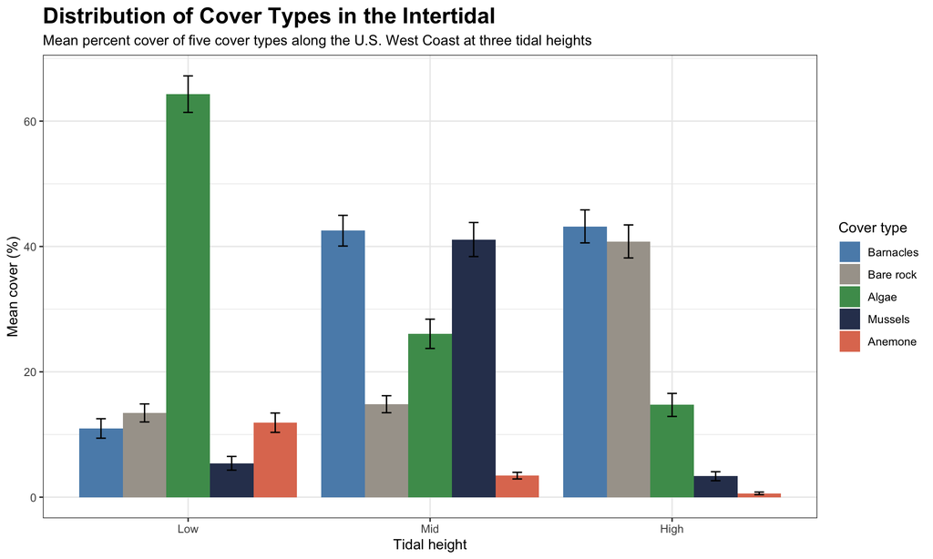

Figure 1: Mean percent cover of five cover types (algae, anemone, bare rock, barnacles, and mussels) across low, mid, and high tide, pooled across 15 intertidal sites along the US Pacific coast (32.9 to 47.7°N). Colored bars show the mean cover of each type at each tidal height, averaged across quadrats (n = 150 per tidal height) and error bars show ±1 standard error. Barnacles combine small, large, and gooseneck barnacles. Cover types can sum to more than 100% within a tidal height because organisms can grow in layers (e.g., algae over barnacles)., so each cover type was scored independently.

```r
IT_long |>
  group_by(tidal_height, cover_type) |>
  summarise(mean_abundance = mean(percent_cover, na.rm = TRUE), # summarize mean percent_cover
            se = sd(percent_cover, na.rm = TRUE) / sqrt(n())) |> # calculate standard error of means
  ggplot(aes(x = tidal_height, y = mean_abundance,
             fill = fct_reorder2(cover_type, tidal_height, mean_abundance))) + #reorders fill by the values of y at the largest values of x
  geom_col(position = "dodge") + # splits up the bar chart into a bar per cover type instead of stacking them on top of each other
  geom_errorbar(aes(ymin = mean_abundance - se, ymax = mean_abundance + se), # add error bars on bars
                position = position_dodge(width = 0.9), # place error bars directly on each bar instead of all over randomly
                width = 0.2) + # make the bars smaller
  scale_fill_manual(values = cover_colors, # add manual color palette
                    labels = c(algae = "Algae", # capitalize legend entries, is there an easier way than spelling them all out?
                               anemone = "Anemone",
                               bare_rock = "Bare rock",
                               barnacles_total = "Barnacles",
                               mussels = "Mussels")) +
  labs(x = "Tidal height", y = "Mean cover (%)", fill = "Cover type",
       title = "Distribution of Cover Types in the Intertidal",
       subtitle = "Mean percent cover of five cover types along the U.S. West Coast at three tidal heights") +
  theme_bw()+
  theme(plot.title = element_text(size=17, face="bold")) # bold plot title
```

## Conclusion

### Questions for TA/Instructor

It wouldn’t let me publish my file because the csv files were on my local drive, how do you work around this?

Also, I feel like this plot took a lot of steps to create, did I do a lot of unnecessary work?

- Especially with the SE bars, is there an easier way to add them?
- Also, with cleaning up the Quadrat column I was looking at the **stringr** package, but there are so many options (pros and cons with that) so I was struggling to decide which one was the simplest way to remove the “.” and “1” in a few Quadrat tide entries.
- Could you mutate to create the total barnacle column in the same code chunk as pivoting to long format or does it have to be beforehand? I tried, but it just added a weird column that didn’t make much sense.